# Class11

Camryn McCann (PID: A15437387)

11/2/2021

#Introduction to the RCSB Protein Data Bank (PDB)

Downloaded the following CSV dile from the PDB site.

```r
db <- read.csv("Data Export Summary.csv", row.names = 1)
head(db)
```

```
##                          X.ray   NMR   EM Multiple.methods Neutron Other  Total
## Protein (only)          142303 11804 5999              177      70    32 160385
## Protein/Oligosaccharide   8414    31  979                5       0     0   9429
## Protein/NA                7491   274 1986                3       0     0   9754
## Nucleic acid (only)       2368  1372   60                8       2     1   3811
## Other                      149    31    3                0       0     0    183
## Oligosaccharide (only)      11     6    0                1       0     4     22
```

> **Q1: What percentage of structures in the PDB are solved by X-Ray and Electron Microscopy.**

```r
round(sum(db$X.ray)/sum(db$Total)*100,2)
```

```
## [1] 87.55
```

```r
round(sum(db$EM)/sum(db$Total)*100,2)
```

```
## [1] 4.92
```

> **Q2: What proportion of structures in the PDB are protein?**

```r
round(db$Total[1]/sum(db$Total)*100,2)
```

```
## [1] 87.36
```

> **Q3: Type HIV in the PDB website search box on the home page and determine how many HIV-1 protease structures are in the current PDB?**

#Visualizing the HIV-1 protease structure

> **Q4: Water molecules normally have 3 atoms. Why do we see just one atom per water molecule in this structure?**

These water molecules only have one atom, which is oxygen, because the 2 hydrogen atoms present are too small to see.

> **Q5: There is a conserved water molecule in the binding site. Can you identify this water molecule? What residue number does this water molecule have (see note below)?**

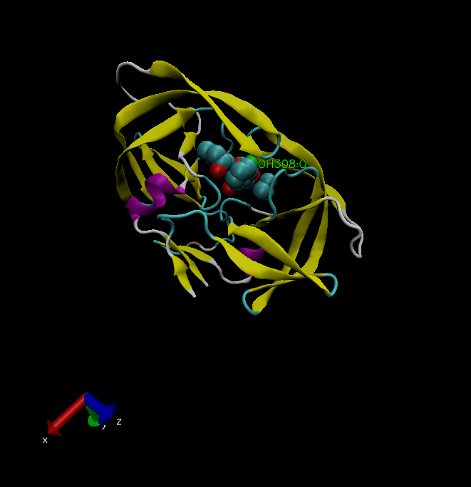

The water molecule is conserved at residue 308.

#Introduction to Bio3D in R

```r
library(bio3d)
```

```r
pdb <- read.pdb("1hsg.pdb")
pdb
```

```
##
##  Call:  read.pdb(file = "1hsg.pdb")
##
##    Total Models#: 1
##      Total Atoms#: 1686,  XYZs#: 5058  Chains#: 2  (values: A B)
##
##      Protein Atoms#: 1514  (residues/Calpha atoms#: 198)
##      Nucleic acid Atoms#: 0  (residues/phosphate atoms#: 0)
##
##      Non-protein/nucleic Atoms#: 172  (residues: 128)
##      Non-protein/nucleic resid values: [ HOH (127), MK1 (1) ]
##
##    Protein sequence:
##       PQITLWQRPLVTIKIGGQLKEALLDTGADDTVLEEMSLPGRWKPKMIGGIGGFIKVRQYD
##       QILIEICGHKAIGTVLVGPTPVNIIGRNLLTQIGCTLNFPQITLWQRPLVTIKIGGQLKE
##       ALLDTGADDTVLEEMSLPGRWKPKMIGGIGGFIKVRQYDQILIEICGHKAIGTVLVGPTP
##       VNIIGRNLLTQIGCTLNF
##
## + attr: atom, xyz, seqres, helix, sheet,
##         calpha, remark, call
```